# Data Exploration Airline On-Time Statistics and Delay Causes

by Samriddhi Singh

Investigation Overview:

I analysed the flight data of april 2020, in wich they gave the delay causes

## dataset overview

1. year
2. month
3. carrier unique airline company code
4. carrier_name airline company name
5. airport destination airport, airport ID
6. airport_name destination airport, airport name
7. arr_flights number of flights arrived to airport (for given month)
8. arr_del15 number of flights delayed at least 15 min (for given month)
9. carrier_ct number of flights delayed due to air carrier, e.g. maintenance or crew problems, aircraft cleaning, baggage loading, fueling, etc. (for given month)
10. weather_ct number of flights delayed due to weather conditions (for given month)
11. nas_ct number of flights delayed due to National Aviation System, e.g. non-extreme weather conditions, airport operations, heavy traffic volume, and air traffic control (for given month)
12. security_ct number of flights delayed due to security, e.g. evacuation of a terminal or concourse, re-boarding of aircraft because of security breach, inoperative screening equipment and/or long lines in excess of 29 minutes at screening areas (for given month)
13. late_aircraft_ct number of flights delayed due to a previous flight using the same aircraft being late (for given month)
14. arr_cancelled number of calcelled flights (for given month)
15. arr_diverted number of diverted flights (for given month)
16. arr_delay total delay time of arrived flights (in minutes)
17. carrier_delay total delay time of arrived flights due to air carrier (in minutes)
18. weather_delay total delay time of arrived flights due to weather (in minutes)
19. nas_delay total delay time of arrived flights due to National Aviation System (in minutes)
20. security_delay total delay time of arrived flights due to security (in minutes)
21. late_aircraft_delay total delay time of arrived flights due to a previous flight using the same aircraft being late (in minutes)

questions:

1) most common carrier name in moth 4 of 2020

2) most frecount types of ct

3) number of flights cancelled to airport per carrier

4)corrolations between delays

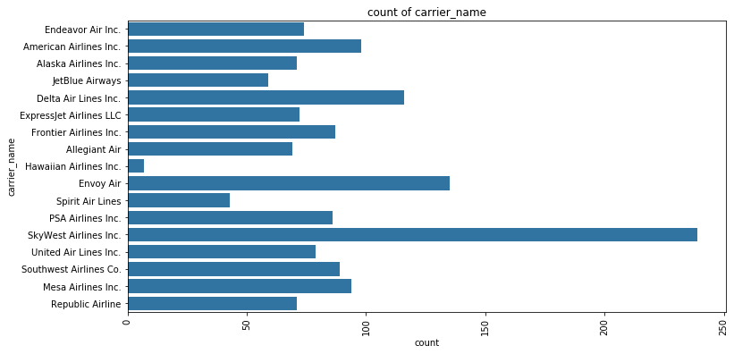

```python
plt.figure(figsize = [12, 6])
blue=sb.color_palette()[0]
sb.countplot(data = df, y = 'carrier_name',color=blue);
plt.xticks(rotation=90)
plt.title('count of carrier_name');
```

In this visualization you can observe the most common carriers.And it is SkyWest Airlines Inc.

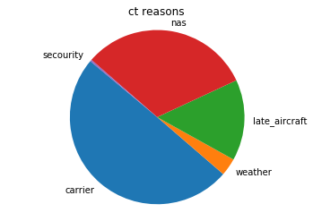

```python
label ='carrier', 'weather','late_aircraft','nas','secourity'
data = [df.carrier_ct.mean(),df.weather_ct.mean(),df.late_aircraft_ct.mean(),
               df.nas_ct.mean(),df.security_ct.mean()]
plt.pie(data, labels=label, startangle=140);
plt.axis('equal')
plt.title('ct reasons');
plt.axis('equal')

plt.axis('equal');
```

this plot shows the most frucount ct with carrier ct being the most common and secourity bearly seen.Wich is interessting beacouse I expectet secourity to be one of the biggest in proportion to the others.

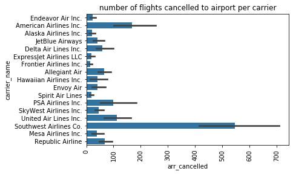

```python
blue=sb.color_palette()[0]
sb.barplot(data = df.sort_values(by=['carrier']),
           y = 'carrier_name', x="arr_cancelled", color = blue)
plt.xticks(rotation=90)
plt.title('number of flights cancelled to airport per carrier');
```

```
corrolation between delays
```

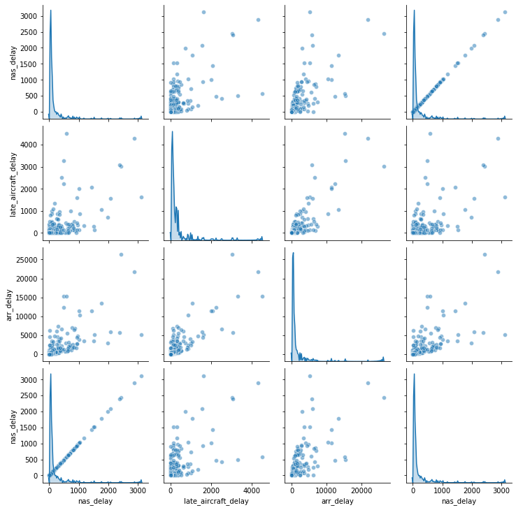

```python
print('corrolation between delays')
sb.pairplot(df,
             vars = ['nas_delay','late_aircraft_delay','arr_delay','nas_delay' ],
             diag_kind = 'kde', plot_kws = {'alpha': 0.5},palette="ch:2.5,-.2,dark=.3");
```

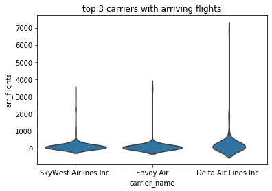

```python
a=df[df.carrier_name=='SkyWest Airlines Inc.' ]
b=df[df.carrier_name=='Envoy Air' ]
c=df[df.carrier_name=='Delta Air Lines Inc.' ]
a_b_c=pd.concat([a,b,c])
a_b_c.carrier_name.value_counts()
base_color = sb.color_palette()[0]
sb.violinplot(data = a_b_c, x = 'carrier_name', y = 'arr_flights',inner=None,color=base_color)
plt.title('top 3 carriers with arriving flights')
```

here I plottet the arriving plotts in the 3 most common carriers  
you can see that the means are quiet low in compereson the the outliers.